# Least Squares Regression

### Example: Beers versus BAC

```r
df <- read.csv('http://people.hsc.edu/faculty-staff/blins/StatsExamples/bac.csv')
# First six rows
head(df)
```

```
##   student beers   bac
## 1       1     5 0.100
## 2       2     2 0.030
## 3       3     9 0.190
## 4       4     8 0.120
## 5       5     3 0.040
## 6       6     7 0.095
```

```r
# Number of rows and columns
dim(df)
```

```
## [1] 16  3
```

```r
# Averages
apply(df, MARGIN = 2, FUN = mean) # Applies the function mean() to the columns. MARGIN = 1 would apply to rows.
```

```
## student   beers     bac
## 8.50000 4.81250 0.07375
```

```r
# Standard deviations
apply(df, MARGIN = 2, FUN = sd)
```

```
##    student      beers        bac
## 4.76095229 2.19753650 0.04413993
```

### Scatterplots

It is very easy to make scatterplots in R.

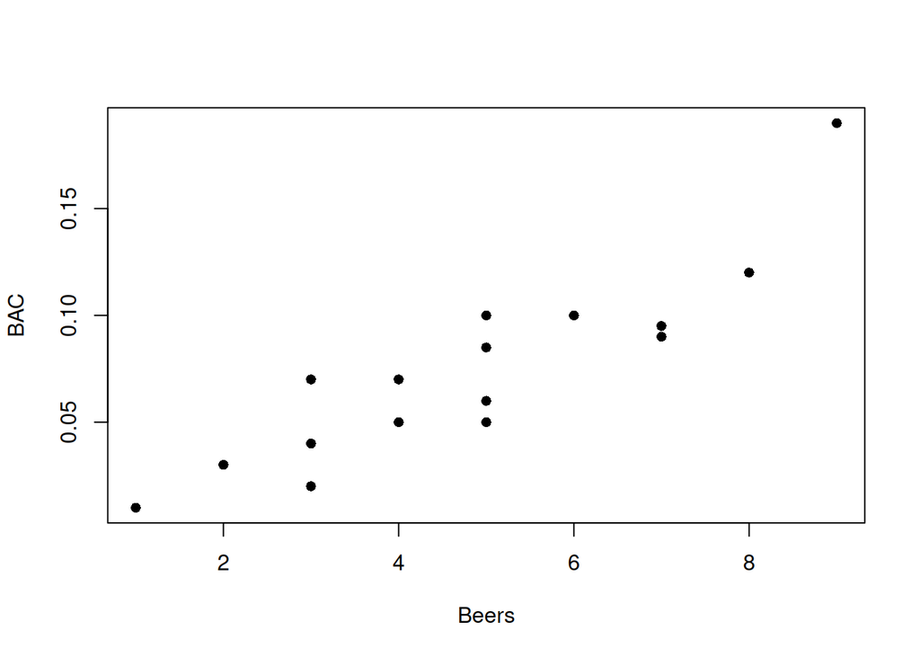

```r
plot(df$beers, df$bac, xlab = "Beers", ylab = "BAC", pch = 16)
```

### Correlation

The `cor()` function calculates the correlation between two different vectors of data.

```r
cor(df$beers, df$bac)
```

```
## [1] 0.8943381
```

### Linear Regression

The command `lm()` will construct a least squares linear regression model for predicting one variable based on another. Here `lm` stands for **linear model**. The syntax is a little different than other commands. Here is an example of how to use it.

```r
myLM <- lm(bac ~ beers, data = df)
myLM
```

```
##
## Call:
## lm(formula = bac ~ beers, data = df)
##
## Coefficients:
## (Intercept)        beers
##    -0.01270      0.01796
```

### Plotting Trendlines

You can add the trendline to the scatterplot with the command `abline()`.

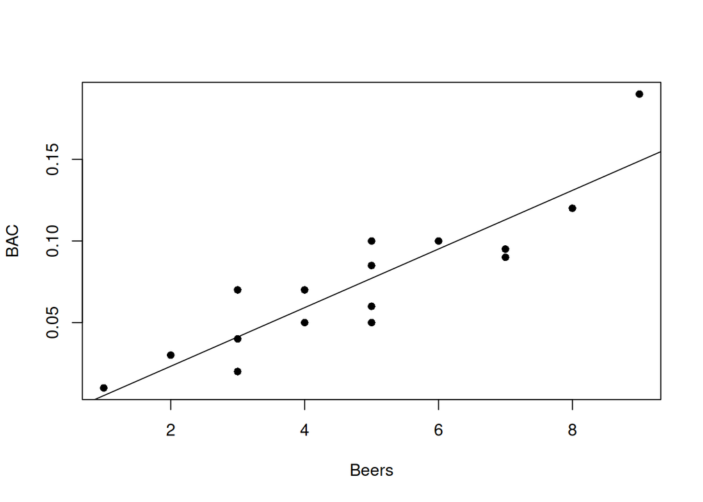

```r
plot(df$beers, df$bac, xlab="Beers", ylab="BAC", pch = 16)
abline(myLM) # Adds the trendline to the scatterplot
```

### Making Predictions

If you want to predict a y-value based on a particular x-value, use the `predict()` function. The arguments of `predict()` are a linear model and a data frame with a header that has the same name as the x-variable in the linear model. In this example, the second argument is a simple data frame with two values for `beers`, one person who drinks 2 beers and another who drinks 8.

```r
predict(myLM, data.frame(beers = c(2,8)))
```

```
##          1          2
## 0.02322692 0.13100949
```

Based on the results, it looks like someone who drinks 2 beers will have an average BAC of about 0.023, while someone who drinks 8 beers will have an average BAC of 0.131.

### Checking Inference Conditions with Residual Plots

The function `resid()` takes a linear model (like `myLM`) and returns the residuals. You can use this to plot the residuals against the x-values which is often useful if you want to assess whether data really follows a linear model and whether the conditions for statistical inference are met.

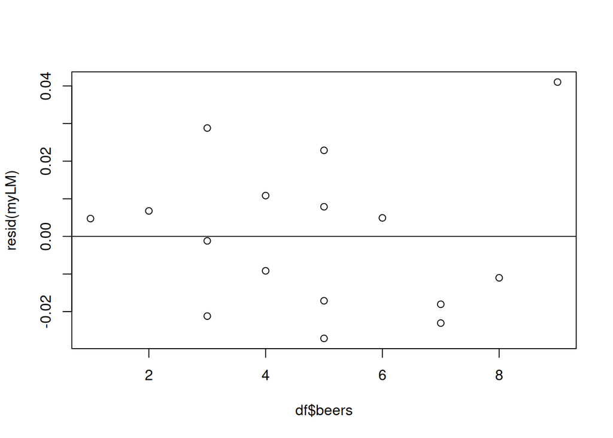

```r
plot(df$beers, resid(myLM))
abline(0,0) # Add line with slope = 0 and y-intercept = 0 to the residual plot
```

It looks like the residuals have a similar variance throughout, although it is hard to tell with a small sample size like this. But if you look at a qqplot, you can see that the residuals are not normally distributed.

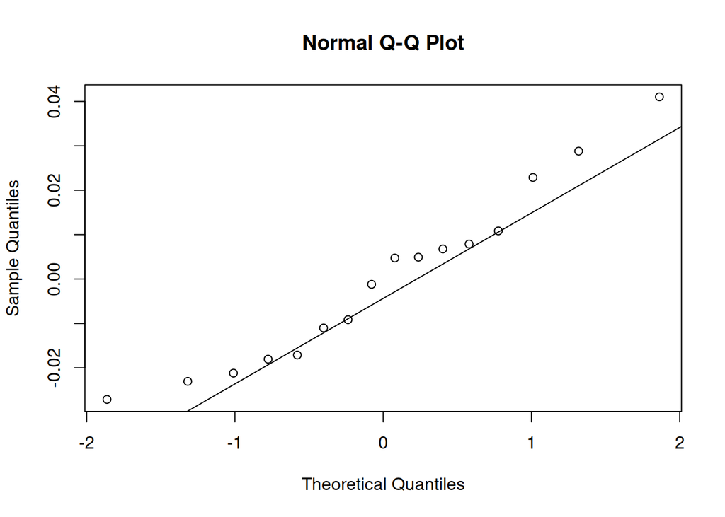

```r
qqnorm(resid(myLM))
qqline(resid(myLM))
```

That’s might affect the reliability of any confidence intervals we make later since the sample size is small ($n = 16$).

### Other Information

A linear model in R contains a lot of useful information that can be accessed using the `summary()` function. This information will be particularly useful when we apply statistical inference techniques to linear regression.

```r
summary(myLM)
```

```
##
## Call:
## lm(formula = bac ~ beers, data = df)
##
## Residuals:
##       Min        1Q    Median        3Q       Max
## -0.027118 -0.017350  0.001773  0.008623  0.041027
##
## Coefficients:
##              Estimate Std. Error t value Pr(>|t|)
## (Intercept) -0.012701   0.012638  -1.005    0.332
## beers        0.017964   0.002402   7.480 2.97e-06 ***
## ---
## Signif. codes:  0 '***' 0.001 '**' 0.01 '*' 0.05 '.' 0.1 ' ' 1
##
## Residual standard error: 0.02044 on 14 degrees of freedom
## Multiple R-squared:  0.7998, Adjusted R-squared:  0.7855
## F-statistic: 55.94 on 1 and 14 DF,  p-value: 2.969e-06
```

You can get an ANOVA table for a linear model using the `anova()` function.

```r
anova(myLM)
```

```
## Analysis of Variance Table
##
## Response: bac
##           Df    Sum Sq   Mean Sq F value    Pr(>F)
## beers      1 0.0233753 0.0233753  55.944 2.969e-06 ***
## Residuals 14 0.0058497 0.0004178
## ---
## Signif. codes:  0 '***' 0.001 '**' 0.01 '*' 0.05 '.' 0.1 ' ' 1
```